# Homework 6

**Due:** Friday, October 30, 11:59pm on Canvas

**Instructions:**

Begin by downloading the HW 6 template from the course website:

https://sta214-f26.github.io/homework/hw_06_template.qmd

Save this template file to your computer, then open it in RStudio. As you complete the assignment, you will write down your answers to all questions in the file, and include all R code in code chunks.

When you have completed the assignment, render your homework to HTML and submit on Canvas. *You must submit the rendered HTML on Canvas to receive full credit!*

**Collaborators and AI statement:** At the top of your assignment, list any collaborators (Dr. Evans does not count – he is a resource, not a collaborator), and provide an AI statement describing your use of AI to complete the questions. If you did not use AI in any way, let me know that too. If you did use AI, provide: the model used, the HW questions on which you used AI, and a summary of the ways in which AI provided assistance. As described in the syllabus, AI use is permitted on homework assignments, but submissions without a complete AI statement may not receive full credit.

**Code guidelines:**

- If a question requires code, and code is not provided, you will not receive full credit
- You will be graded on the quality of your code. In addition to being correct, your code should also be easy to read

# Using diagnostic plots

Suppose we observe data $(X_1, Y_1),...,(X_n, Y_n)$, and fit the Poisson regression model

$$Y_i \sim Poisson(\lambda_i)$$

$$\log(\lambda_i) = \beta_0 + \beta_1
X_i$$

To check our model fit, we create the diagnostic plots shown below:

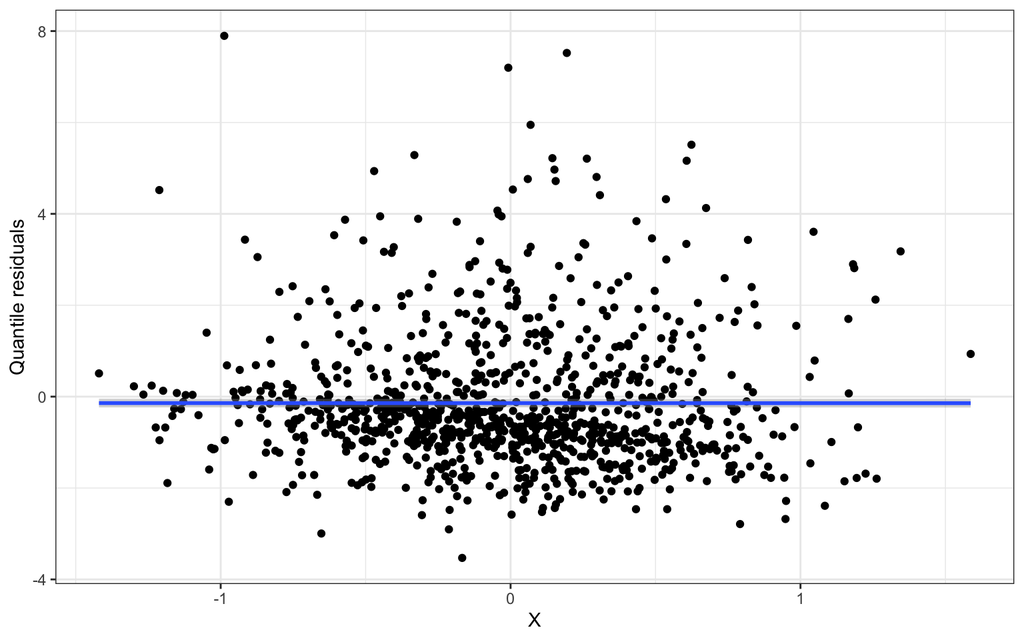

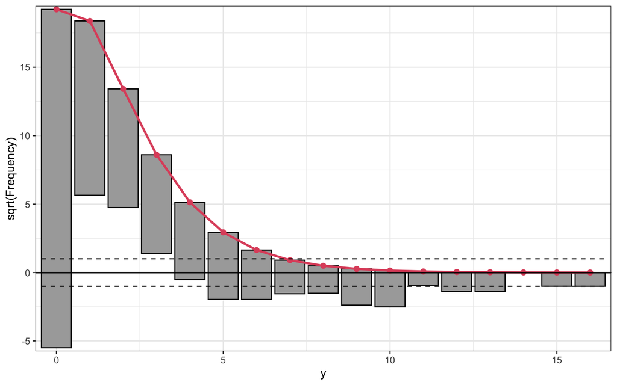

#### Question 1

Do the Poisson regression assumptions appear to be satisfied?

- Explain your reasoning – how are you using the plots to check the assumptions?
- If the assumptions are not satisfied:
  - Which particular assumptions are violated?
  - How would you modify the model?

# Diagnostic plots, part II

Below are two rootograms from two different models. For both models, the shape assumption is satisfied, but the distribution assumption is not. One model suffers from *overdispersion* in the response (the variance is bigger than the model expects), while the other model suffers from *underdispersion* in the response (the variance is smaller than the model expects).

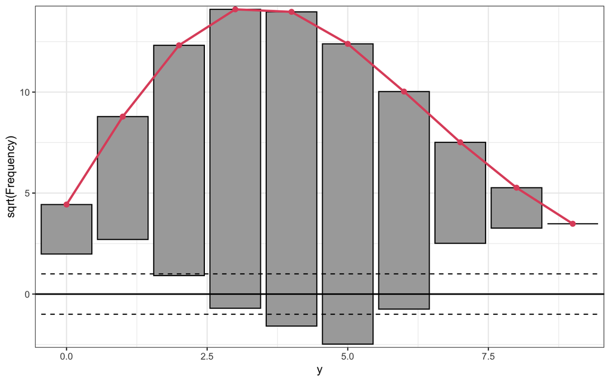

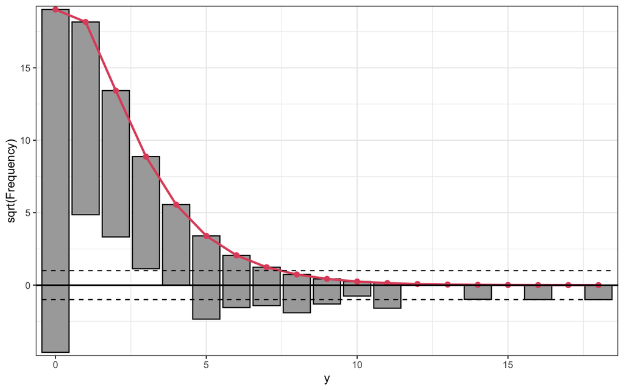

#### Question 2

Which rootogram shows evidence of overdispersion, and which shows evidence of underdispersion? Explain your reasoning, and which features of the rootograms you are using to make your decision.

# Overdispersion effects

The Poisson regression model assumes that $Y_i$ follows a Poisson distribution, which requires that the mean and variance of $Y_i$ are the same. However, it is common to encounter data in which the variance of $Y_i$ is much greater than the mean of $Y_i$, a situation called *overdispersion*. In this portion of the assignment, we will use simulations to explore the effect of overdispersion on inference about our model.

## Simulating data and computing a confidence interval

To begin, let’s generate data from the model

$$X_i \sim N(0, 0.5)$$
$$\log(\lambda_i) = X_i$$
$$Y_i \sim Poisson(\lambda_i)$$
Note that the Poisson regression assumptions are satisfied for this model. The true slope of our model is $\beta_1 = 1$.

#### Question 3

Run the code below to generate data from this model, fit the Poisson regression model in R, and create a 95% confidence interval for $\beta_1$. Does your interval contain $\beta_1$?

```r
n <- 1000
beta0 <- 0
beta1 <- 1
x <- rnorm(n, sd = 0.5)
y1 <- rpois(n, lambda = exp(beta0 + beta1*x))

m1 <- glm(y1 ~ x, family = poisson)

upper <- summary(m1)$coefficients[2,1] +
    1.96*summary(m1)$coefficients[2,2]
lower <- summary(m1)$coefficients[2,1] -
    1.96*summary(m1)$coefficients[2,2]
```

## Repeating

Now let’s run the simulation 500 times, and estimate the true coverage of our confidence intervals (that is, the fraction of times the interval contains the true $\beta_1$):

```r
n <- 1000
nsim <- 500
beta0 <- 0
beta1 <- 1
contains_beta <- rep(0, nsim)
for(i in 1:nsim){
  x <- rnorm(n, sd = 0.5)
  y1 <- rpois(n, lambda = exp(beta0 + beta1*x))

  m1 <- glm(y1 ~ x, family = poisson)

  upper <- summary(m1)$coefficients[2,1] +
      1.96*summary(m1)$coefficients[2,2]
  lower <- summary(m1)$coefficients[2,1] -
      1.96*summary(m1)$coefficients[2,2]

  contains_beta[i] <- upper > beta1 && lower < beta1
}

mean(contains_beta)
```

#### Question 4

Run the code. What fraction of times did the confidence intervals contain the true $\beta_1$?

## Changing the distribution

Now what happens if we change the distribution of $Y$? The negative binomial distribution is another count distribution, which is different from the Poisson. In particular, the variance of the negative binomial is greater than the mean! Let’s generate negative binomial data (violating the Poisson distribution assumption and creating overdispersion), and see how the coverage of our confidence intervals change.

#### Question 5

Modify your code from question 4, but this time instead of generating $Y$ from a Poisson distribution, generate $Y$ from a negative binomial, using:

```r
y1 <- rnbinom(n, size=0.5, mu=exp(beta0 + beta1*x))
```

How does the coverage change compared to question 4?

## Modifying our model

#### Question 7

Now modify the code from question 5, so that instead of fitting a Poisson model you fit a *quasi*-Poisson model (`family = quasipoisson`). Use the quasi-Poisson model and the appropriate $t$-distribution to calculate the confidence intervals. What is the coverage when using the quasi-Poisson?

# Understanding the estimated dispersion parameter

The dispersion parameter $\phi$ tells us about the relationship between the mean and variance of the response variable. For a Poisson regression model, we assume that $\phi = 1$. However, real data often shows evidence of overdispersion, in which case we wish to estimate $\phi$.

In class, the estimator discussed is

$$\widehat{\phi} = \dfrac{\sum
\limits_{i=1}^n e_{(P)i}^2}{n-p}$$

Why does this estimate $\phi$? Because

$$\sum \limits_{i=1}^n e_{(P)i}^2 \approx
\phi \chi^2_{n-p}$$

That is, the approximate distribution of the numerator is $\phi$ times a chi-squared distribution with $n - p$ degrees of freedom. We know that the mean of a $\chi^2_{n-p}$ distribution is $n-p$, so on average $\widehat{\phi} \approx \phi$. In particular, if our Poisson distribution assumption is correct and $\phi = 1$, then $\widehat{\phi} \approx 1$ as well.

In this portion of the homework, you will use simulation to verify that $\sum \limits_{i=1}^n e_{(P)i}^2 \approx \phi \chi^2_{n-p}$. (The mathematical explanation is a bit beyond the scope of the course, but I am happy to chat more about the math in office hours if you are interested!)

The code below simulates 100 observations from a Poisson regression model in which all assumptions are satisfied, and then calculates the numerator for $\widehat{\phi}$:

```r
n <- 100
beta0 <- 0
beta1 <- 1

x <- rnorm(n, sd = 0.5)
y <- rpois(n, lambda = exp(beta0 + beta1*x))

m1 <- glm(y ~ x, family = poisson)
sum(residuals(m1, "pearson")^2)
```

#### Question 8

Repeat the simulation `nsim = 1000` times, and store the resulting sums of squared residuals. Compare the distribution of the calculated numerators to a $\chi^2_{98}$ distribution:

- Calculate the mean and variance of the 1000 calculated numerators, and compare to the mean and variance of a $\chi^2_{98}$
- Create a density histogram of the 1000 calculated numerators, and overlay the density function of a $\chi^2_{98}$